# Untitled

Satoshi

5/18/2019

```r
library(dplyr)
library(MASS)
library(ggplot2)
library(pROC)
library(ROCR)
library(tableone)
library(glmnet)
library(caret)
library(leaps)
library(tree)
library(randomForest)
library(rpart)
library(rattle)
library(rpart.plot)
library(RColorBrewer)
library(gbm)
library(e1071)
library(ROCR)
library(tableone)
library(splines)
library(gam)
library(mgcv)
```

Let me explain again the purpose of this study simply.

Recently, many studies have shown that abnormal chloride concentration, especially hyperchloremia, is independently associated with AKI. However, these studies have some concerns.

First, these studies only focused on chloride ion, which concentration usually increases or decreases along with sodium ion concentration. From perspective of acid-base phenomena, chloride ion concentration should be judged along with sodium ion concentration. Thus, the difference between sodium and chloride (SID) is important. That’s why we want to use sodium and SID as well as chloride in this study.

Second, some of the studies only used logistic regression, which assumes a linear association between log odds of AKI and chloride ion concentration. This might be wrong because both high and low ion concentration could be worse in terms of AKI (i.e. non-linear). That’s why we want to use ML tecnhiques.

In this study, we would like to assess associations between AKI and chloride, sodium and SID using ML technique. If possible, we want to compare which variable, among chloride, sodium and SID, is the most importantly and strongly associated with AKI.

# Data wrangling

```r
df<-read.csv("sid_aki_study.csv",header=T)

#For outcomes/predictors with substantial missig data, IPW should be used?
#Exclude CKD, rrt before admision
df_1<-df%>%filter(creat1<=3)%>%mutate(aki=case_when(.$AKIstage==0~0,.$AKIstage%in%c(1,2,3)~1))%>%
  mutate(gender=case_when(.$gender=="Female"~0,
                          .$gender=="Male"~1,
                          TRUE~as.numeric(NA)),
         pre_rrt=case_when(.$rrt_bin==1&first_rrtoffset<=0~1,
                          TRUE~0))%>%filter(pre_rrt==0)

df_1$ethnicity[df_1$ethnicity ==""|
             df_1$ethnicity == "Native American"|
             df_1$ethnicity == "Other/Unknow"] <- "Other/Unknown"

df_1$surgery<-NA
df_1$surgery[df_1$hospitalAdmitSource =="Operating Room"|
             df_1$hospitalAdmitSource == "PACU"] <- 1
df_1$surgery[df_1$hospitalAdmitSource =="Acute Care/Floor"|
             df_1$hospitalAdmitSource == "Chest Pain Center"|
             df_1$hospitalAdmitSource == "Direct Admit"|
               df_1$hospitalAdmitSource == "Emergency Department"|
               df_1$hospitalAdmitSource == "Floor"|
               df_1$hospitalAdmitSource == "ICU"|
               df_1$hospitalAdmitSource == "ICU to SDU"|
               df_1$hospitalAdmitSource == "Observation"|
               df_1$hospitalAdmitSource == "Other"|
               df_1$hospitalAdmitSource == "Other Hospital"|
               df_1$hospitalAdmitSource == "Other ICU"|
               df_1$hospitalAdmitSource == "Recovery Room"|
               df_1$hospitalAdmitSource == "Step-Down Unit (SDU)"] <- 0

#Categorizing Na, Cl, and SID
df_2<-df_1%>%mutate(cl_adm_cat=case_when(.$chloride_first<98 ~ 1,
                              .$chloride_first>=98 & .$chloride_first<=110 ~ 0,
                              .$chloride_first>110 ~ 2,
                                TRUE ~ as.numeric(NA)),
         na_adm_cat=case_when(.$sodium_first>145 ~ 2,
                                .$sodium_first<=145  & .$sodium_first>=135 ~ 0,
                                .$sodium_first<135 ~ 1,
                                TRUE ~ as.numeric(NA)),
         sid_adm_cat=case_when(.$SID_first>37 ~ 2,
                                .$SID_first<=37  & .$SID_first>=31 ~ 0,
                                .$SID_first<31 ~ 1,
                                TRUE ~ as.numeric(NA)),
         cl_24_min_cat=case_when(.$chloride_min_24<98 ~ 1,
                              .$chloride_min_24>=98 & .$chloride_min_24<=110 ~ 0,
                              .$chloride_min_24>110 ~ 2,
                                TRUE ~ as.numeric(NA)),
         cl_24_max_cat=case_when(.$chloride_max_24<98 ~ 1,
                              .$chloride_max_24>=98 & .$chloride_max_24<=110 ~ 0,
                              .$chloride_max_24>110 ~ 2,
                                TRUE ~ as.numeric(NA)),
         na_24_min_cat=case_when(.$sodium_min_24>145 ~ 2,
                                .$sodium_min_24<=145  & .$sodium_min_24>=135 ~ 0,
                                .$sodium_min_24<135 ~ 1,
                                TRUE ~ as.numeric(NA)),
         na_24_max_cat=case_when(.$sodium_max_24>145 ~ 2,
                                .$sodium_max_24<=145  & .$sodium_max_24>=135 ~ 0,
                                .$sodium_max_24<135 ~ 1,
                                TRUE ~ as.numeric(NA)),
         sid_24_min_cat=case_when(.$SID_min_24>37 ~ 2,
                                .$SID_min_24<=37  & .$SID_min_24>=31 ~ 0,
                                .$SID_min_24<3 ~ 1,
                                TRUE ~ as.numeric(NA)),
         sid_24_max_cat=case_when(.$SID_max_24>37 ~ 2,
                                .$SID_max_24<=37  & .$SID_max_24>=31 ~ 0,
                                .$SID_max_24<31 ~ 1,
                                TRUE ~ as.numeric(NA)),
         cl_24_mean_cat=case_when(.$chloride_twa_24<98 ~ 1,
                              .$chloride_twa_24>=98 & .$chloride_twa_24<=110 ~ 0,
                              .$chloride_twa_24>110 ~ 2,
                                TRUE ~ as.numeric(NA)),
         na_24_mean_cat=case_when(.$sodium_twa_24>145 ~ 2,
                                .$sodium_twa_24<=145  & .$sodium_twa_24>=135 ~ 0,
                                .$sodium_twa_24<135 ~ 1,
                                TRUE ~ as.numeric(NA)),
         sid_24_mean_cat=case_when(.$SID_twa_24>37 ~ 2,
                                .$SID_twa_24<=37  & .$SID_twa_24>=31 ~ 0,
                                .$SID_twa_24<31 ~ 1,
                                TRUE ~ as.numeric(NA)),
         delta_cl_d1=chloride_twa_24-chloride_first,
         delta_na_d1=sodium_twa_24-sodium_first,
         delta_sid_d1=SID_twa_24-SID_first)%>%
   mutate_at(c("gender","pasthistory_chf","pasthistory_pvd","pasthistory_hypertension","pasthistory_copd","pasthistory_diabetes","cl_adm_cat","na_adm_cat","sid_adm_cat","cl_24_min_cat","cl_24_max_cat","na_24_min_cat","na_24_max_cat","sid_24_min_cat","sid_24_max_cat","ethnicity","cl_24_mean_cat","na_24_mean_cat","sid_24_mean_cat","aki","surgery"),as.factor)

#Focusing on medical patients
df_me<-df_2%>%filter(surgery==0)
```

As the primary outcome, we would like to focus on AKI. We have mainly two types of variables based on the phase: 1) variables at admission, 2) variables for the first 24 hours. Analyses were conducted based on the phase as follows.

# Variables at admission

```r
#Wrangling
df_adm<-df_me%>%filter(!is.na(chloride_first),!is.na(sodium_first),!is.na(SID_first),!is.na(aki))
nrow(df_adm)
```

```
## [1] 36001
```

```r
#table one
CreateTableOne(vars=c("gender","age_fixed","weight","pao2_first","paco2_first","pH_first","baseexcess_first","albumin_first","bilirubin_first","BUN_first","wbc_first","platelets_first","hematocrit_first","hemoglobin_first","glucose_first","pasthistory_chf","pasthistory_pvd","pasthistory_hypertension","pasthistory_copd","pasthistory_diabetes","sodium_first","chloride_first","SID_first","cl_adm_cat","na_adm_cat","sid_adm_cat","creat1"),strata="aki",data=df_adm)
```

```
##                                   Stratified by aki
##                                    0               1               p
##   n                                 31158            4843
##   gender = 1 (%)                    16344 (52.5)     2646 (54.7)    0.005
##   age_fixed (mean (sd))             60.58 (18.96)   66.81 (15.96)  <0.001
##   weight (mean (sd))                81.51 (25.11)   87.82 (28.47)  <0.001
##   pao2_first (mean (sd))           135.88 (101.95) 133.39 (101.16)  0.380
##   paco2_first (mean (sd))           45.67 (20.00)   46.00 (19.88)   0.561
##   pH_first (mean (sd))               7.32 (0.13)     7.29 (0.14)   <0.001
##   baseexcess_first (mean (sd))      -1.48 (8.42)    -3.86 (8.22)   <0.001
##   albumin_first (mean (sd))          3.34 (0.75)     2.94 (0.76)   <0.001
##   bilirubin_first (mean (sd))        0.86 (1.66)     1.51 (3.16)   <0.001
##   BUN_first (mean (sd))             21.59 (15.48)   29.84 (18.69)  <0.001
##   wbc_first (mean (sd))             11.79 (6.44)    14.06 (8.69)   <0.001
##   platelets_first (mean (sd))      231.05 (99.38)  215.88 (117.10) <0.001
##   hematocrit_first (mean (sd))      36.62 (7.48)    34.64 (7.77)   <0.001
##   hemoglobin_first (mean (sd))      12.15 (2.65)    11.32 (2.62)   <0.001
##   glucose_first (mean (sd))        177.09 (127.87) 180.18 (116.30)  0.154
##   pasthistory_chf = 1 (%)            3713 (12.3)     1044 (22.1)   <0.001
##   pasthistory_pvd = 1 (%)            1113 ( 3.7)      278 ( 5.9)   <0.001
##   pasthistory_hypertension = 1 (%)  13871 (46.1)     2705 (57.2)   <0.001
##   pasthistory_copd = 1 (%)           6786 (22.5)     1313 (27.8)   <0.001
##   pasthistory_diabetes = 1 (%)       5058 (16.8)      856 (18.1)    0.029
##   sodium_first (mean (sd))         137.77 (5.79)   137.53 (6.23)    0.010
##   chloride_first (mean (sd))       103.18 (7.13)   102.84 (7.43)    0.002
##   SID_first (mean (sd))             34.59 (4.63)    34.69 (5.02)    0.146
##   cl_adm_cat (%)                                                   <0.001
##      0                              22543 (72.4)     3285 (67.8)
##      1                               5138 (16.5)      969 (20.0)
##      2                               3477 (11.2)      589 (12.2)
##   na_adm_cat (%)                                                   <0.001
##      0                              23211 (74.5)     3306 (68.3)
##      1                               6525 (20.9)     1243 (25.7)
##      2                               1422 ( 4.6)      294 ( 6.1)
##   sid_adm_cat (%)                                                   0.003
##      0                              18683 (60.0)     2777 (57.3)
##      1                               5252 (16.9)      870 (18.0)
##      2                               7223 (23.2)     1196 (24.7)
##   creat1 (mean (sd))                 1.16 (0.53)     1.31 (0.58)   <0.001
##                                   Stratified by aki
```

[output cut: 23 more lines]

```
##   chloride_first (mean (sd))
##   SID_first (mean (sd))
##   cl_adm_cat (%)
##      0
##      1
##      2
##   na_adm_cat (%)
##      0
##      1
##      2
##   sid_adm_cat (%)
##      0
##      1
##      2
##   creat1 (mean (sd))
```

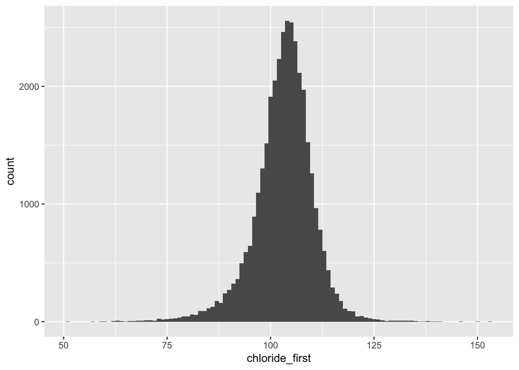

```r
#Distribution
#Time-weighted mean chloride
df_adm%>%ggplot()+
  geom_histogram(aes(chloride_first),binwidth = 1)
```

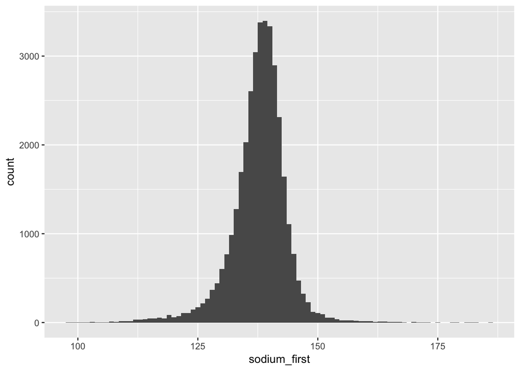

```r
#Time-weighted mean sodium
df_adm%>%ggplot()+
  geom_histogram(aes(sodium_first),binwidth = 1)
```

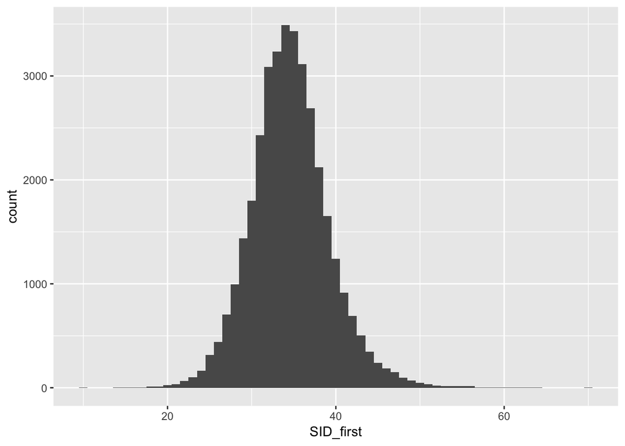

```r
#Time-weighted mean (Na-Cl)
df_adm%>%ggplot()+
  geom_histogram(aes(SID_first),binwidth = 1)
```

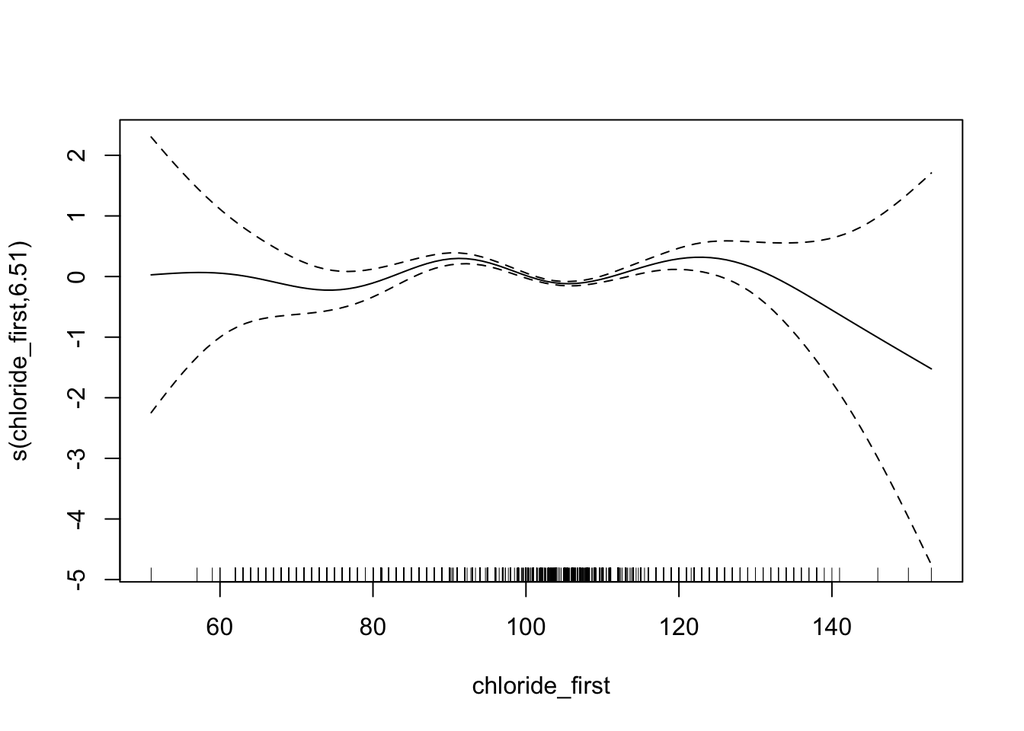

```r
#Association between AKI and ions.
#chloride
gam<-gam(aki~s(chloride_first,bs="tp",k=10),data=df_adm,family="binomial")
plot(gam)
```

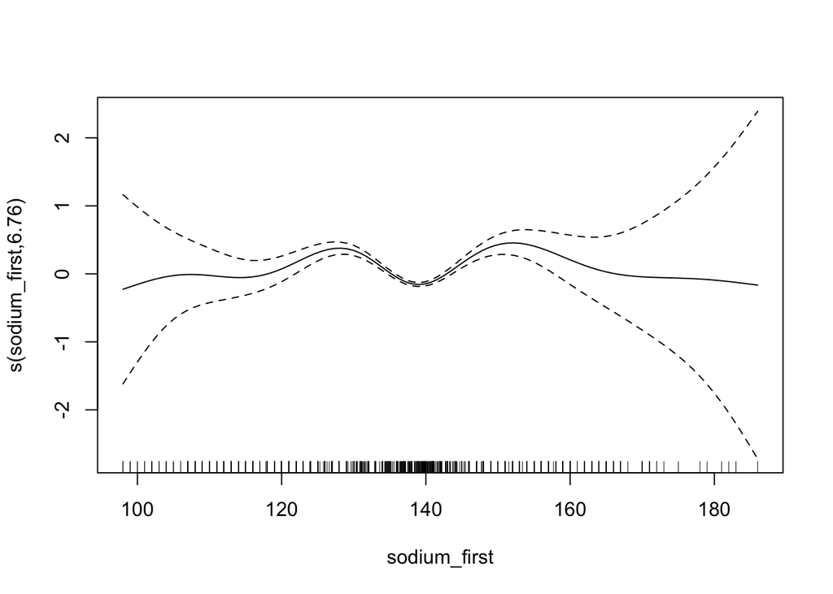

```r
#sodium
gam<-gam(aki~s(sodium_first,bs="tp",k=10),data=df_adm,family="binomial")
plot(gam)
```

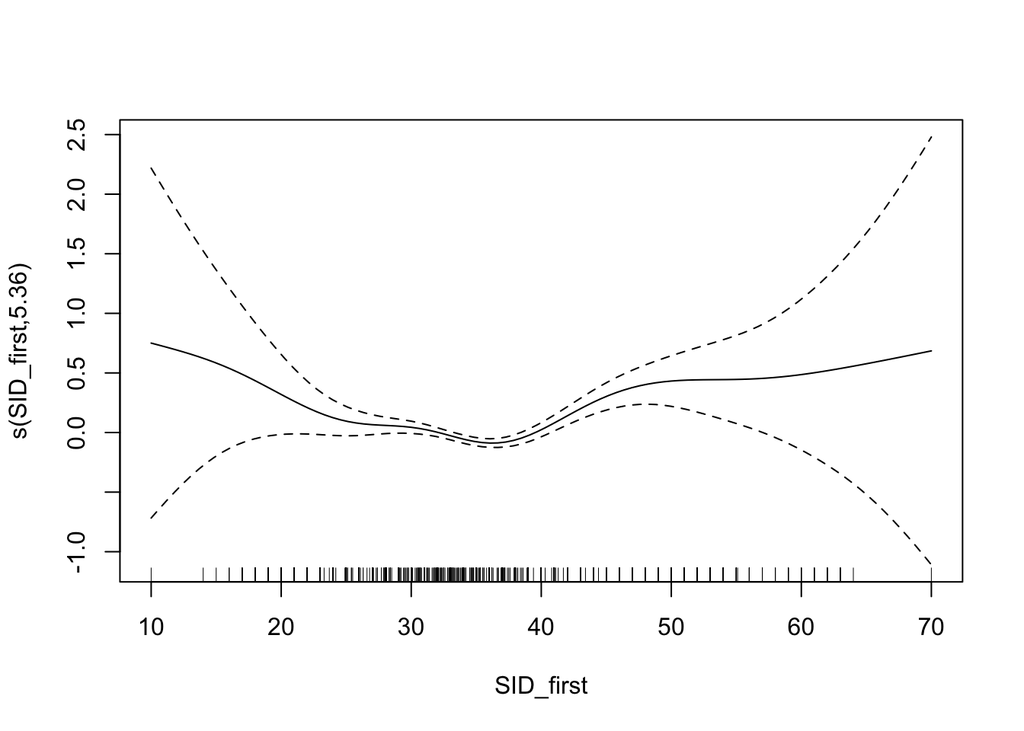

```r
#Na-Cl
gam<-gam(aki~s(SID_first,bs="tp",k=10),data=df_adm,family="binomial")
plot(gam)
```

As we can see, the association between those variables and AKI is non-linear (maybe U-shape). Thus, using Cl, Na, and SID as continuous variables in logistic regression is wrong. One solution is using Cl, Na, and SID as categorical variables.

```r
#Analysis using categorical Cl, Na, and SID
#Logistic regression
model<-glm(aki~cl_adm_cat+na_adm_cat+sid_adm_cat+
      gender+age_fixed+pasthistory_chf+pasthistory_pvd+pasthistory_hypertension+pasthistory_copd+pasthistory_diabetes+ethnicity+creat1,data=df_adm,family="binomial")
summary(model)
```

```
##
## Call:
## glm(formula = aki ~ cl_adm_cat + na_adm_cat + sid_adm_cat + gender +
##     age_fixed + pasthistory_chf + pasthistory_pvd + pasthistory_hypertension +
##     pasthistory_copd + pasthistory_diabetes + ethnicity + creat1,
##     family = "binomial", data = df_adm)
##
## Deviance Residuals:
##     Min       1Q   Median       3Q      Max
## -1.1637  -0.5782  -0.4874  -0.3923   2.4885
##
## Coefficients:
##                            Estimate Std. Error z value Pr(>|z|)
## (Intercept)               -3.273739   0.082078 -39.886  < 2e-16 ***
## cl_adm_cat1                0.069880   0.054244   1.288  0.19766
## cl_adm_cat2                0.055496   0.062518   0.888  0.37471
## na_adm_cat1                0.248741   0.046912   5.302 1.14e-07 ***
## na_adm_cat2                0.241121   0.078731   3.063  0.00219 **
## sid_adm_cat1               0.108815   0.048288   2.253  0.02423 *
## sid_adm_cat2               0.028798   0.043219   0.666  0.50520
## gender1                    0.100354   0.032453   3.092  0.00199 **
## age_fixed                  0.015599   0.001018  15.329  < 2e-16 ***
## pasthistory_chf1           0.404293   0.042193   9.582  < 2e-16 ***
## pasthistory_pvd1           0.103569   0.076735   1.350  0.17712
## pasthistory_hypertension1  0.173337   0.034045   5.091 3.55e-07 ***
## pasthistory_copd1          0.076917   0.040223   1.912  0.05584 .
## pasthistory_diabetes1      0.051068   0.042872   1.191  0.23359
## ethnicityAsian            -0.493131   0.149971  -3.288  0.00101 **
## ethnicityCaucasian        -0.324983   0.049748  -6.533 6.46e-11 ***
## ethnicityHispanic         -0.137414   0.088247  -1.557  0.11943
## ethnicityOther/Unknown    -0.143061   0.080799  -1.771  0.07663 .
## creat1                     0.274659   0.028843   9.522  < 2e-16 ***
## ---
## Signif. codes:  0 '***' 0.001 '**' 0.01 '*' 0.05 '.' 0.1 ' ' 1
##
## (Dispersion parameter for binomial family taken to be 1)
##
##     Null deviance: 27654  on 34811  degrees of freedom
## Residual deviance: 26705  on 34793  degrees of freedom
##   (1189 observations deleted due to missingness)
## AIC: 26743
##
## Number of Fisher Scoring iterations: 5
```

```r
exp(cbind(OR=coef(model), confint.default(model)))
```

```
##                                   OR      2.5 %     97.5 %
## (Intercept)               0.03786459 0.03223803 0.04447316
## cl_adm_cat1               1.07237923 0.96421875 1.19267252
## cl_adm_cat2               1.05706497 0.93516143 1.19485932
## na_adm_cat1               1.28240966 1.16975502 1.40591363
## na_adm_cat2               1.27267464 1.09069091 1.48502267
## sid_adm_cat1              1.11495660 1.01427300 1.22563473
## sid_adm_cat2              1.02921644 0.94562486 1.12019737
## gender1                   1.10556273 1.03743153 1.17816832
## age_fixed                 1.01572140 1.01369761 1.01774923
## pasthistory_chf1          1.49824223 1.37932621 1.62741036
## pasthistory_pvd1          1.10912223 0.95424988 1.28912998
## pasthistory_hypertension1 1.18926733 1.11250106 1.27133072
## pasthistory_copd1         1.07995210 0.99808351 1.16853601
## pasthistory_diabetes1     1.05239472 0.96757707 1.14464749
## ethnicityAsian            0.61071144 0.45517681 0.81939251
## ethnicityCaucasian        0.72253945 0.65541430 0.79653932
## ethnicityHispanic         0.87160888 0.73317198 1.03618532
## ethnicityOther/Unknown    0.86670152 0.73976479 1.01541941
## creat1                    1.31608223 1.24374526 1.39262637
```

```r
#With lab data
model<-glm(aki~cl_adm_cat+na_adm_cat+sid_adm_cat+
      gender+age_fixed+pasthistory_chf+pasthistory_pvd+pasthistory_hypertension+pasthistory_copd+pasthistory_diabetes+ethnicity+creat1+
        albumin_first+hemoglobin_first+glucose_first,data=df_adm,family="binomial")
summary(model)
```

```
##
## Call:
## glm(formula = aki ~ cl_adm_cat + na_adm_cat + sid_adm_cat + gender +
##     age_fixed + pasthistory_chf + pasthistory_pvd + pasthistory_hypertension +
##     pasthistory_copd + pasthistory_diabetes + ethnicity + creat1 +
##     albumin_first + hemoglobin_first + glucose_first, family = "binomial",
##     data = df_adm)
##
## Deviance Residuals:
##     Min       1Q   Median       3Q      Max
## -1.2645  -0.5221  -0.3985  -0.2975   2.7957
##
## Coefficients:
##                             Estimate Std. Error z value Pr(>|z|)
## (Intercept)               -1.5987881  0.2640084  -6.056 1.40e-09 ***
## cl_adm_cat1               -0.0001505  0.1179542  -0.001  0.99898
## cl_adm_cat2               -0.1784136  0.1525639  -1.169  0.24223
## na_adm_cat1                0.1657347  0.1056282   1.569  0.11664
## na_adm_cat2                0.2423812  0.1789190   1.355  0.17551
## sid_adm_cat1               0.1617693  0.1190974   1.358  0.17437
## sid_adm_cat2               0.1911659  0.0903946   2.115  0.03445 *
## gender1                    0.0842870  0.0717327   1.175  0.23999
## age_fixed                  0.0125572  0.0022452   5.593 2.23e-08 ***
## pasthistory_chf1           0.4136060  0.0929172   4.451 8.53e-06 ***
## pasthistory_pvd1          -0.0054901  0.1789080  -0.031  0.97552
## pasthistory_hypertension1  0.2310504  0.0739423   3.125  0.00178 **
## pasthistory_copd1         -0.0073442  0.0887443  -0.083  0.93404
## pasthistory_diabetes1      0.0285332  0.1078861   0.264  0.79141
## ethnicityAsian            -0.4097312  0.3156726  -1.298  0.19430
## ethnicityCaucasian        -0.3369358  0.1120219  -3.008  0.00263 **
## ethnicityHispanic         -0.0814402  0.2028825  -0.401  0.68811
## ethnicityOther/Unknown    -0.2597346  0.1765533  -1.471  0.14125
## creat1                     0.2787193  0.0642429   4.339 1.43e-05 ***
## albumin_first             -0.7005280  0.0567005 -12.355  < 2e-16 ***
## hemoglobin_first           0.0313912  0.0157012   1.999  0.04558 *
## glucose_first              0.0008278  0.0002889   2.865  0.00417 **
## ---
## Signif. codes:  0 '***' 0.001 '**' 0.01 '*' 0.05 '.' 0.1 ' ' 1
##
## (Dispersion parameter for binomial family taken to be 1)
##
##     Null deviance: 6222.8  on 9027  degrees of freedom
## Residual deviance: 5785.4  on 9006  degrees of freedom
##   (26973 observations deleted due to missingness)
## AIC: 5829.4
##
## Number of Fisher Scoring iterations: 5
```

```r
#Backward selection
#step(model,scope=list(lower=~cl_adm_cat+na_adm_cat+sid_adm_cat,upper=model),direction="backward",k=2)
```

In this model, only high SID is associated with AKI.

Another way is using other ML methods such as spline and tree. However, I am not good at those methods. I would appreciate it if you could give me some advice and correct the following codes.

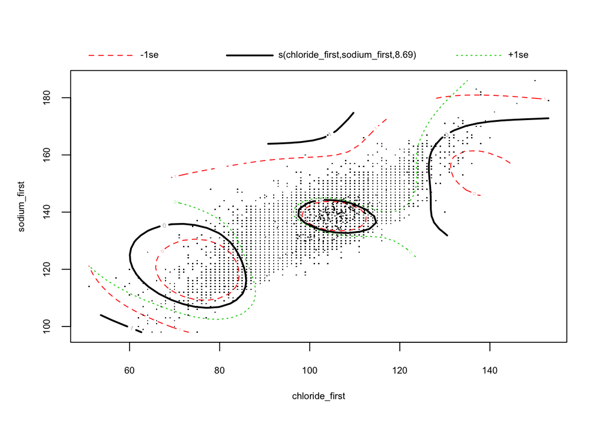

```r
#Analysis using continuous Cl, Na, and SID
#Spline
#Cl vs. Na
gam<-gam(aki~s(chloride_first,sodium_first,bs="tp",k=10),data=df_adm,family="binomial")
plot(gam)
```

```r
#Main predictors
gam<-gam(aki~s(chloride_first,bs="tp",k=10)+s(sodium_first,bs="tp",k=10)+s(SID_first,bs="tp",k=10)+
           gender+age_fixed+pasthistory_chf+pasthistory_pvd+pasthistory_hypertension+pasthistory_copd+pasthistory_diabetes+ethnicity+creat1,data=df_adm,family="binomial")
summary(gam)
```

```
##
## Family: binomial
## Link function: logit
##
## Formula:
## aki ~ s(chloride_first, bs = "tp", k = 10) + s(sodium_first,
##     bs = "tp", k = 10) + s(SID_first, bs = "tp", k = 10) + gender +
##     age_fixed + pasthistory_chf + pasthistory_pvd + pasthistory_hypertension +
##     pasthistory_copd + pasthistory_diabetes + ethnicity + creat1
##
## Parametric coefficients:
##                            Estimate Std. Error z value Pr(>|z|)
## (Intercept)               -3.171683   0.080493 -39.403  < 2e-16 ***
## gender1                    0.106513   0.032525   3.275 0.001057 **
## age_fixed                  0.015754   0.001021  15.434  < 2e-16 ***
## pasthistory_chf1           0.399126   0.042328   9.429  < 2e-16 ***
## pasthistory_pvd1           0.105147   0.076896   1.367 0.171500
## pasthistory_hypertension1  0.173975   0.034110   5.100 3.39e-07 ***
## pasthistory_copd1          0.069184   0.040385   1.713 0.086692 .
## pasthistory_diabetes1      0.049200   0.042990   1.144 0.252441
## ethnicityAsian            -0.496103   0.150212  -3.303 0.000958 ***
## ethnicityCaucasian        -0.324998   0.049855  -6.519 7.08e-11 ***
## ethnicityHispanic         -0.138407   0.088394  -1.566 0.117394
## ethnicityOther/Unknown    -0.145758   0.080910  -1.801 0.071626 .
## creat1                     0.267686   0.028956   9.245  < 2e-16 ***
## ---
## Signif. codes:  0 '***' 0.001 '**' 0.01 '*' 0.05 '.' 0.1 ' ' 1
##
## Approximate significance of smooth terms:
##                     edf Ref.df Chi.sq  p-value
## s(chloride_first) 2.490  3.478  6.555    0.136
## s(sodium_first)   6.614  7.594 76.236 3.38e-13 ***
## s(SID_first)      4.967  5.980 36.058 3.06e-06 ***
## ---
## Signif. codes:  0 '***' 0.001 '**' 0.01 '*' 0.05 '.' 0.1 ' ' 1
##
## Rank: 39/40
## R-sq.(adj) =  0.0263   Deviance explained = 3.72%
## UBRE = -0.23361  Scale est. = 1         n = 34812
```

```r
#More covariates
model<-gam(aki~s(chloride_first,bs="tp",k=10)+s(sodium_first,bs="tp",k=10)+s(SID_first,bs="tp",k=10)+s(pao2_first,bs="tp",k=10)+s(paco2_first,bs="tp",k=10)+s(pH_first,bs="tp",k=10)+s(baseexcess_first,bs="tp",k=10)+s(albumin_first,bs="tp",k=10)+s(wbc_first,bs="tp",k=10)+s(platelets_first,bs="tp",k=10)+s(hemoglobin_first,bs="tp",k=10)+s(glucose_first,bs="tp",k=10)+
      gender+age_fixed+pasthistory_chf+pasthistory_pvd+pasthistory_hypertension+pasthistory_copd+pasthistory_diabetes+ethnicity+creat1,data=df_adm,family="binomial")
summary(model)
```

```
##
## Family: binomial
## Link function: logit
##
## Formula:
## aki ~ s(chloride_first, bs = "tp", k = 10) + s(sodium_first,
##     bs = "tp", k = 10) + s(SID_first, bs = "tp", k = 10) + s(pao2_first,
##     bs = "tp", k = 10) + s(paco2_first, bs = "tp", k = 10) +
##     s(pH_first, bs = "tp", k = 10) + s(baseexcess_first, bs = "tp",
##     k = 10) + s(albumin_first, bs = "tp", k = 10) + s(wbc_first,
##     bs = "tp", k = 10) + s(platelets_first, bs = "tp", k = 10) +
##     s(hemoglobin_first, bs = "tp", k = 10) + s(glucose_first,
##     bs = "tp", k = 10) + gender + age_fixed + pasthistory_chf +
##     pasthistory_pvd + pasthistory_hypertension + pasthistory_copd +
##     pasthistory_diabetes + ethnicity + creat1
##
## Parametric coefficients:
##                             Estimate Std. Error z value Pr(>|z|)
## (Intercept)               -2.951e+00  6.095e-01  -4.842 1.28e-06 ***
## gender1                   -2.105e-01  2.479e-01  -0.849 0.395800
## age_fixed                  2.767e-02  7.983e-03   3.467 0.000527 ***
## pasthistory_chf1           1.918e-01  3.023e-01   0.634 0.525829
## pasthistory_pvd1           9.028e-01  5.156e-01   1.751 0.079985 .
## pasthistory_hypertension1  2.262e-01  2.570e-01   0.880 0.378690
## pasthistory_copd1         -2.950e-02  2.754e-01  -0.107 0.914699
## pasthistory_diabetes1     -4.242e-02  3.926e-01  -0.108 0.913940
## ethnicityAsian            -5.800e+01  2.740e+07   0.000 0.999998
## ethnicityCaucasian        -6.666e-01  3.657e-01  -1.823 0.068344 .
## ethnicityHispanic          2.411e-01  5.952e-01   0.405 0.685381
## ethnicityOther/Unknown    -5.514e-01  5.791e-01  -0.952 0.341022
## creat1                    -2.146e-01  2.330e-01  -0.921 0.357137
## ---
## Signif. codes:  0 '***' 0.001 '**' 0.01 '*' 0.05 '.' 0.1 ' ' 1
##
## Approximate significance of smooth terms:
##                       edf Ref.df Chi.sq p-value
## s(chloride_first)   1.504  2.215  3.119 0.31983
## s(sodium_first)     1.000  1.000  0.174 0.67657
## s(SID_first)        6.267  7.286  8.801 0.28110
## s(pao2_first)       1.000  1.000  0.166 0.68360
## s(paco2_first)      1.000  1.000  0.124 0.72516
## s(pH_first)         1.000  1.000  0.024 0.87734
## s(baseexcess_first) 5.287  6.401 17.798 0.01119 *
## s(albumin_first)    2.169  2.758 11.735 0.00911 **
## s(wbc_first)        7.471  8.222 14.548 0.08466 .
## s(platelets_first)  1.000  1.000  0.662 0.41592
## s(hemoglobin_first) 1.000  1.000  0.323 0.56975
## s(glucose_first)    2.522  3.250  3.569 0.34800
## ---
## Signif. codes:  0 '***' 0.001 '**' 0.01 '*' 0.05 '.' 0.1 ' ' 1
##
## Rank: 120/121
## R-sq.(adj) =  0.225   Deviance explained = 26.2%
## UBRE = -0.17799  Scale est. = 1         n = 688
```

```r
#How to diagnose colinear relationship??
```

# Variables for the first 24 hours

Using variables in the first 24 hours, I did the same analyses as above.

```r
#Wrangling
df_24h<-df_me%>%filter(!is.na(chloride_twa_24),!is.na(sodium_twa_24),!is.na(SID_twa_24),!is.na(aki))
nrow(df_24h)
```

```
## [1] 64468
```

```r
#table one
CreateTableOne(vars=c("fio2_min_24" ,   "pao2_min_24"  ,  "paco2_min_24","pH_min_24","aniongap_min_24","basedeficit_min_24","baseexcess_min_24","peep_min24","pao2_max_24","paco2_max_24","pH_max_24", "aniongap_max_24"     ,"basedeficit_max_24"  , "baseexcess_max_24"   ,"peep_max24","glucose_min_24","hemoglobin_min_24","hematocrit_min_24"   ,"platelets_min_24"  , "BUN_min_24"    ,"wbc_min_24"   , "albumin_min_24"         ,"bilirubin_min24" ,"glucose_max_24","hemoglobin_max_24","hematocrit_max_24","platelets_max_24","BUN_max_24","wbc_max_24","albumin_max_24","bilirubin_max24"),strata="aki",data=df_24h)
```

```
##                                 Stratified by aki
##                                  0               1               p
##   n                               57015            7453
##   fio2_min_24 (mean (sd))          0.42 (0.23)     0.50 (0.25)   <0.001
##   pao2_min_24 (mean (sd))        100.28 (67.48)   92.02 (61.02)  <0.001
##   paco2_min_24 (mean (sd))        40.52 (14.07)   38.78 (13.36)  <0.001
##   pH_min_24 (mean (sd))            7.32 (0.12)     7.27 (0.14)   <0.001
##   aniongap_min_24 (mean (sd))      9.68 (4.01)    10.92 (4.74)   <0.001
##   basedeficit_min_24 (mean (sd))   4.90 (5.31)     5.29 (4.79)    0.060
##   baseexcess_min_24 (mean (sd))   -1.28 (7.68)    -4.00 (8.28)   <0.001
##   peep_min24 (mean (sd))           5.54 (2.17)     5.87 (2.56)   <0.001
##   pao2_max_24 (mean (sd))        149.06 (105.64) 164.95 (111.60) <0.001
##   paco2_max_24 (mean (sd))        47.76 (20.18)   49.96 (20.92)  <0.001
##   pH_max_24 (mean (sd))            7.38 (0.10)     7.37 (0.10)   <0.001
##   aniongap_max_24 (mean (sd))     12.40 (5.65)    13.92 (6.01)   <0.001
##   basedeficit_max_24 (mean (sd))   6.56 (6.10)     8.54 (6.76)   <0.001
##   baseexcess_max_24 (mean (sd))    0.59 (7.37)    -0.63 (7.20)   <0.001
##   peep_max24 (mean (sd))           6.16 (2.98)     7.01 (4.09)   <0.001
##   glucose_min_24 (mean (sd))     113.38 (40.98)  116.63 (46.41)  <0.001
##   hemoglobin_min_24 (mean (sd))   11.35 (2.55)    10.51 (2.45)   <0.001
##   hematocrit_min_24 (mean (sd))   34.31 (7.27)    32.23 (7.32)   <0.001
##   platelets_min_24 (mean (sd))   210.90 (95.26)  190.90 (101.18) <0.001
##   BUN_min_24 (mean (sd))          19.85 (14.08)   30.28 (18.84)  <0.001
##   wbc_min_24 (mean (sd))          10.24 (5.61)    11.95 (7.62)   <0.001
##   albumin_min_24 (mean (sd))       3.15 (0.75)     2.76 (0.73)   <0.001
##   bilirubin_min24 (mean (sd))      0.82 (1.41)     1.44 (2.96)   <0.001
##   glucose_max_24 (mean (sd))     192.78 (135.09) 211.98 (117.94) <0.001
##   hemoglobin_max_24 (mean (sd))   12.37 (2.43)    11.69 (2.43)   <0.001
##   hematocrit_max_24 (mean (sd))   37.30 (6.88)    35.72 (7.21)   <0.001
##   platelets_max_24 (mean (sd))   236.92 (105.25) 222.57 (114.37) <0.001
##   BUN_max_24 (mean (sd))          22.95 (15.71)   35.11 (19.90)  <0.001
##   wbc_max_24 (mean (sd))          12.32 (6.84)    15.27 (9.42)   <0.001
##   albumin_max_24 (mean (sd))       3.32 (0.75)     2.97 (0.74)   <0.001
##   bilirubin_max24 (mean (sd))      0.93 (1.55)     1.64 (3.18)   <0.001
##                                 Stratified by aki
##                                  test
##   n
##   fio2_min_24 (mean (sd))
##   pao2_min_24 (mean (sd))
##   paco2_min_24 (mean (sd))
```

[output cut: 13 more lines]

```
##   hemoglobin_min_24 (mean (sd))
##   hematocrit_min_24 (mean (sd))
##   platelets_min_24 (mean (sd))
##   BUN_min_24 (mean (sd))
##   wbc_min_24 (mean (sd))
##   albumin_min_24 (mean (sd))
##   bilirubin_min24 (mean (sd))
##   glucose_max_24 (mean (sd))
##   hemoglobin_max_24 (mean (sd))
##   hematocrit_max_24 (mean (sd))
##   platelets_max_24 (mean (sd))
##   BUN_max_24 (mean (sd))
##   wbc_max_24 (mean (sd))
##   albumin_max_24 (mean (sd))
##   bilirubin_max24 (mean (sd))
```

```r
CreateTableOne(vars=c("hst_hr_day1","me_hr_day1","lest_sys_day1","me_sys_day1","lest_dia_day1","me_dia_day1","hst_temp"),strata="aki",data=df_24h)
```

```
##                            Stratified by aki
##                             0              1              p      test
##   n                          57015           7453
##   hst_hr_day1 (mean (sd))   106.34 (23.36) 112.46 (25.08) <0.001
##   me_hr_day1 (mean (sd))     85.15 (16.73)  89.76 (18.01) <0.001
##   lest_sys_day1 (mean (sd))  92.07 (21.61)  81.34 (22.69) <0.001
##   me_sys_day1 (mean (sd))   121.40 (19.00) 115.55 (19.84) <0.001
##   lest_dia_day1 (mean (sd))  47.58 (13.89)  40.70 (14.25) <0.001
##   me_dia_day1 (mean (sd))    66.99 (11.92)  62.85 (12.07) <0.001
##   hst_temp (mean (sd))       36.84 (4.31)   37.04 (4.40)  <0.001
```

```r
CreateTableOne(vars=c("chloride_min_24","chloride_max_24","chloride_twa_24","sodium_min_24","sodium_max_24","sodium_twa_24","SID_min_24","SID_max_24","SID_twa_24","cl_24_mean_cat","na_24_mean_cat","sid_24_mean_cat","creat1"),strata="aki",data=df_24h)
```

```
##                              Stratified by aki
##                               0              1              p      test
##   n                            57015           7453
##   chloride_min_24 (mean (sd)) 101.76 (6.60)  101.39 (6.90)  <0.001
##   chloride_max_24 (mean (sd)) 105.12 (6.12)  104.78 (7.00)  <0.001
##   chloride_twa_24 (mean (sd)) 103.67 (5.91)  103.22 (6.63)  <0.001
##   sodium_min_24 (mean (sd))   137.04 (5.16)  136.58 (5.60)  <0.001
##   sodium_max_24 (mean (sd))   139.33 (4.66)  139.27 (5.62)   0.361
##   sodium_twa_24 (mean (sd))   138.28 (4.61)  137.99 (5.37)  <0.001
##   SID_min_24 (mean (sd))       35.28 (4.43)   35.19 (4.80)   0.123
##   SID_max_24 (mean (sd))       34.21 (4.41)   34.49 (4.93)  <0.001
##   SID_twa_24 (mean (sd))       34.61 (4.22)   34.77 (4.66)   0.002
##   cl_24_mean_cat (%)                                        <0.001
##      0                         43422 (76.2)    5110 (68.6)
##      1                          7611 (13.3)    1383 (18.6)
##      2                          5982 (10.5)     960 (12.9)
##   na_24_mean_cat (%)                                        <0.001
##      0                         44905 (78.8)    5250 (70.4)
##      1                          9828 (17.2)    1709 (22.9)
##      2                          2282 ( 4.0)     494 ( 6.6)
##   sid_24_mean_cat (%)                                       <0.001
##      0                         35008 (61.4)    4163 (55.9)
##      1                          9067 (15.9)    1352 (18.1)
##      2                         12940 (22.7)    1938 (26.0)
##   creat1 (mean (sd))            1.14 (0.51)    1.30 (0.57)  <0.001
```

```r
#glm(aki~cl_24_min_cat+na_24_min_cat+sid_24_min_cat+cl_24_max_cat+na_24_max_cat+sid_24_max_cat,data=df_2,family="binomial")%>%summary()
#could be protective for cl_24_min_cat=2, thus, no sense for this model. We should use time_weighted mean.

#Analysis using categorical Cl, Na, and SID
#Logistic regression
model<-glm(aki~cl_24_mean_cat+na_24_mean_cat+sid_24_mean_cat+
      me_hr_day1+me_sys_day1+hst_temp+hemoglobin_min_24+platelets_min_24+albumin_min_24+wbc_max_24+mechvent_day01+urineoutput_total_24+
      gender+age_fixed+pasthistory_chf+pasthistory_pvd+pasthistory_hypertension+pasthistory_copd+pasthistory_diabetes+ethnicity+creat1,data=df_24h,family="binomial")
summary(model)
```

```
##
## Call:
## glm(formula = aki ~ cl_24_mean_cat + na_24_mean_cat + sid_24_mean_cat +
##     me_hr_day1 + me_sys_day1 + hst_temp + hemoglobin_min_24 +
##     platelets_min_24 + albumin_min_24 + wbc_max_24 + mechvent_day01 +
##     urineoutput_total_24 + gender + age_fixed + pasthistory_chf +
##     pasthistory_pvd + pasthistory_hypertension + pasthistory_copd +
##     pasthistory_diabetes + ethnicity + creat1, family = "binomial",
##     data = df_24h)
##
## Deviance Residuals:
##     Min       1Q   Median       3Q      Max
## -2.0016  -0.5142  -0.3727  -0.2669   4.3702
##
## Coefficients:
##                             Estimate Std. Error z value Pr(>|z|)
## (Intercept)               -2.521e+00  2.936e-01  -8.586  < 2e-16 ***
## cl_24_mean_cat1            2.127e-01  6.385e-02   3.332 0.000863 ***
## cl_24_mean_cat2           -1.465e-01  6.963e-02  -2.105 0.035331 *
## na_24_mean_cat1            1.081e-01  5.506e-02   1.964 0.049538 *
## na_24_mean_cat2            2.204e-01  8.709e-02   2.530 0.011395 *
## sid_24_mean_cat1           5.393e-02  5.514e-02   0.978 0.328044
## sid_24_mean_cat2           1.064e-01  5.087e-02   2.092 0.036399 *
## me_hr_day1                 1.170e-02  1.145e-03  10.214  < 2e-16 ***
## me_sys_day1               -6.172e-03  1.083e-03  -5.698 1.21e-08 ***
## hst_temp                   1.332e-02  5.167e-03   2.577 0.009963 **
## hemoglobin_min_24         -5.323e-03  8.211e-03  -0.648 0.516801
## platelets_min_24          -2.029e-03  2.037e-04  -9.957  < 2e-16 ***
## albumin_min_24            -3.892e-01  3.009e-02 -12.937  < 2e-16 ***
## wbc_max_24                 3.206e-02  2.179e-03  14.709  < 2e-16 ***
## mechvent_day01             8.989e-01  4.093e-02  21.959  < 2e-16 ***
## urineoutput_total_24      -1.857e-04  1.638e-05 -11.335  < 2e-16 ***
## gender1                    1.540e-01  3.819e-02   4.034 5.49e-05 ***
## age_fixed                  1.084e-02  1.245e-03   8.711  < 2e-16 ***
## pasthistory_chf1           5.453e-01  4.832e-02  11.286  < 2e-16 ***
## pasthistory_pvd1           9.934e-02  9.176e-02   1.083 0.278984
## pasthistory_hypertension1  3.147e-01  3.951e-02   7.965 1.65e-15 ***
## pasthistory_copd1         -4.719e-02  4.638e-02  -1.018 0.308906
## pasthistory_diabetes1      3.017e-01  5.007e-02   6.025 1.69e-09 ***
## ethnicityAsian            -4.008e-01  1.812e-01  -2.212 0.026940 *
## ethnicityCaucasian        -4.152e-01  5.907e-02  -7.029 2.08e-12 ***
## ethnicityHispanic         -3.495e-01  1.019e-01  -3.431 0.000601 ***
## ethnicityOther/Unknown    -3.588e-01  9.876e-02  -3.634 0.000280 ***
## creat1                     1.302e-01  3.385e-02   3.846 0.000120 ***
## ---
## Signif. codes:  0 '***' 0.001 '**' 0.01 '*' 0.05 '.' 0.1 ' ' 1
##
## (Dispersion parameter for binomial family taken to be 1)
##
##     Null deviance: 23155  on 31823  degrees of freedom
## Residual deviance: 20369  on 31796  degrees of freedom
##   (32644 observations deleted due to missingness)
## AIC: 20425
##
## Number of Fisher Scoring iterations: 5
```

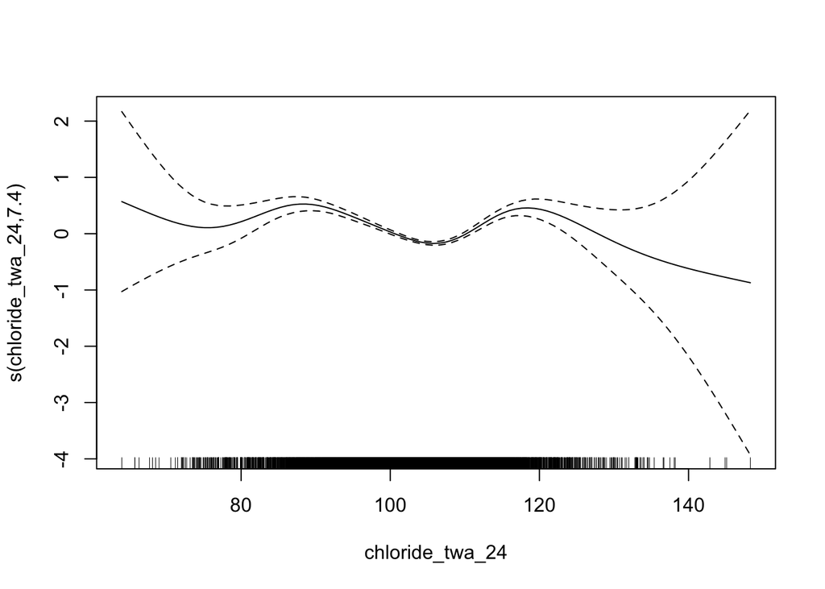

```r
#Analysis using continuous Cl, Na, and SID
#Spline
#chloride
gam<-gam(aki~s(chloride_twa_24,bs="tp",k=10),data=df_24h,family="binomial")
plot(gam)
```

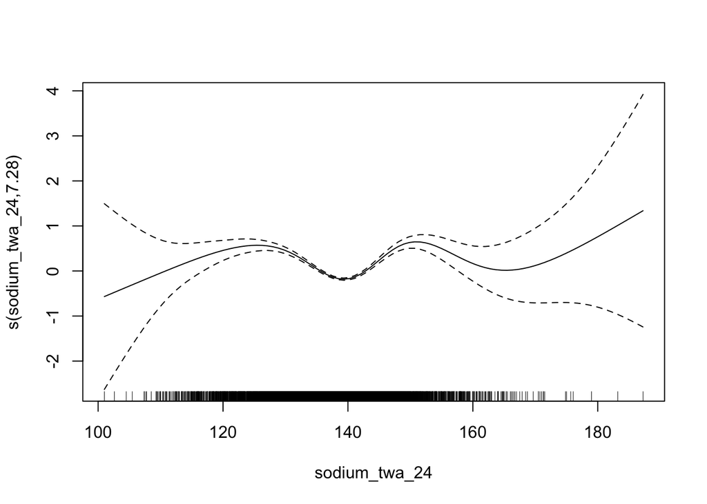

```r
#sodium
gam<-gam(aki~s(sodium_twa_24,bs="tp",k=10),data=df_24h,family="binomial")
plot(gam)
```

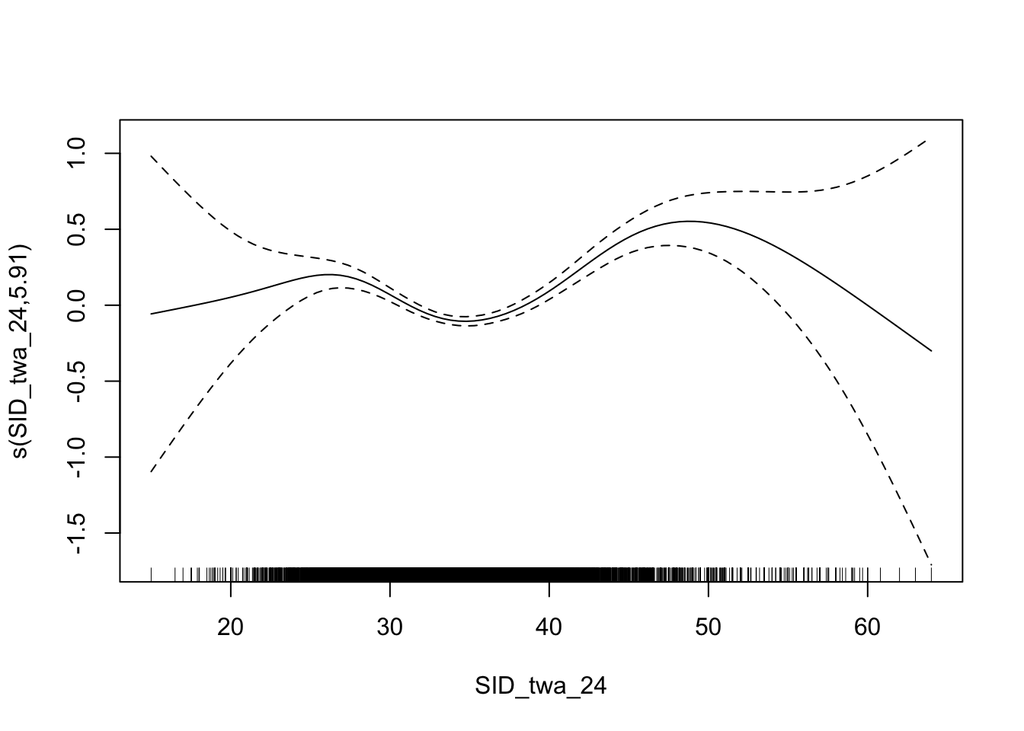

```r
#Na-Cl
gam<-gam(aki~s(SID_twa_24,bs="tp",k=10),data=df_24h,family="binomial")
plot(gam)
```

```r
#Main predictors
model<-gam(aki~s(chloride_twa_24,bs="tp",k=10)+s(sodium_twa_24,bs="tp",k=10)+s(SID_twa_24,bs="tp",k=10)+me_hr_day1+me_sys_day1+hst_temp+hemoglobin_min_24+platelets_min_24+albumin_min_24+wbc_max_24+mechvent_day01+
      gender+age_fixed+pasthistory_chf+pasthistory_pvd+pasthistory_hypertension+pasthistory_copd+pasthistory_diabetes+ethnicity,data=df_2,family="binomial")
summary(model)
```

```
##
## Family: binomial
## Link function: logit
##
## Formula:
## aki ~ s(chloride_twa_24, bs = "tp", k = 10) + s(sodium_twa_24,
##     bs = "tp", k = 10) + s(SID_twa_24, bs = "tp", k = 10) + me_hr_day1 +
##     me_sys_day1 + hst_temp + hemoglobin_min_24 + platelets_min_24 +
##     albumin_min_24 + wbc_max_24 + mechvent_day01 + gender + age_fixed +
##     pasthistory_chf + pasthistory_pvd + pasthistory_hypertension +
##     pasthistory_copd + pasthistory_diabetes + ethnicity
##
## Parametric coefficients:
##                             Estimate Std. Error z value Pr(>|z|)
## (Intercept)               -2.2443653  0.2046921 -10.965  < 2e-16 ***
## me_hr_day1                 0.0111276  0.0008271  13.453  < 2e-16 ***
## me_sys_day1               -0.0078926  0.0007819 -10.095  < 2e-16 ***
## hst_temp                   0.0078093  0.0034292   2.277 0.022770 *
## hemoglobin_min_24         -0.0102070  0.0060773  -1.680 0.093050 .
## platelets_min_24          -0.0024460  0.0001499 -16.313  < 2e-16 ***
## albumin_min_24            -0.3835275  0.0219802 -17.449  < 2e-16 ***
## wbc_max_24                 0.0328548  0.0015658  20.983  < 2e-16 ***
## mechvent_day01             0.8197224  0.0296387  27.657  < 2e-16 ***
## gender1                    0.1682320  0.0274448   6.130 8.80e-10 ***
## age_fixed                  0.0151330  0.0008941  16.926  < 2e-16 ***
## pasthistory_chf1           0.5142027  0.0348920  14.737  < 2e-16 ***
## pasthistory_pvd1           0.1000399  0.0676739   1.478 0.139337
## pasthistory_hypertension1  0.2989230  0.0288381  10.366  < 2e-16 ***
## pasthistory_copd1         -0.0498660  0.0339212  -1.470 0.141547
## pasthistory_diabetes1      0.3304309  0.0364822   9.057  < 2e-16 ***
## ethnicityAsian            -0.4525115  0.1205129  -3.755 0.000173 ***
## ethnicityCaucasian        -0.3992546  0.0443905  -8.994  < 2e-16 ***
## ethnicityHispanic         -0.3589016  0.0757611  -4.737 2.17e-06 ***
## ethnicityOther/Unknown    -0.2708670  0.0674369  -4.017 5.90e-05 ***
## ---
## Signif. codes:  0 '***' 0.001 '**' 0.01 '*' 0.05 '.' 0.1 ' ' 1
##
## Approximate significance of smooth terms:
##                      edf Ref.df Chi.sq  p-value
## s(chloride_twa_24) 2.816  3.684  4.723    0.268
## s(sodium_twa_24)   5.800  6.947 32.621 2.89e-05 ***
## s(SID_twa_24)      2.400  3.107  3.570    0.313
## ---
## Signif. codes:  0 '***' 0.001 '**' 0.01 '*' 0.05 '.' 0.1 ' ' 1
##
## R-sq.(adj) =  0.0883   Deviance explained = 11.1%
## UBRE = -0.32535  Scale est. = 1         n = 56146
```

## Creating training and test set

```r
#Exclude chronic kidney dysfunction and high Cre ad admission
df_24h_1<-df_24h%>%dplyr::select(aki,cl_24_mean_cat,na_24_mean_cat,sid_24_mean_cat,me_hr_day1,me_sys_day1,hst_temp,hemoglobin_min_24,platelets_min_24,albumin_min_24,wbc_max_24,mechvent_day01,gender,age_fixed,pasthistory_chf,pasthistory_pvd,pasthistory_hypertension,pasthistory_copd,pasthistory_diabetes,ethnicity,chloride_twa_24,sodium_twa_24,SID_twa_24,creat1,urineoutput_total_24)%>%na.omit()
colnames(df_24h_1)
```

```
##  [1] "aki"                      "cl_24_mean_cat"
##  [3] "na_24_mean_cat"           "sid_24_mean_cat"
##  [5] "me_hr_day1"               "me_sys_day1"
##  [7] "hst_temp"                 "hemoglobin_min_24"
##  [9] "platelets_min_24"         "albumin_min_24"
## [11] "wbc_max_24"               "mechvent_day01"
## [13] "gender"                   "age_fixed"
## [15] "pasthistory_chf"          "pasthistory_pvd"
## [17] "pasthistory_hypertension" "pasthistory_copd"
## [19] "pasthistory_diabetes"     "ethnicity"
## [21] "chloride_twa_24"          "sodium_twa_24"
## [23] "SID_twa_24"               "creat1"
## [25] "urineoutput_total_24"
```

```r
# Creating training set and test set
set.seed(123)
train=sample(c(TRUE,FALSE), nrow(df_24h_1),rep=TRUE)
test=(!train)
x_train=model.matrix(aki~.,df_24h_1[train,])[,-1]
y_train=df_24h_1[train,]$aki
x_test=model.matrix(aki~.,df_24h_1[test,])[,-1]
y_test=df_24h_1[test,]$aki
```

# Decision tree

```r
tree<-rpart(as.factor(aki)~.,data=df_24h_1,control=rpart.control(minsplit=10, cp=0.0005))
printcp(tree)
```

```
##
## Classification tree:
## rpart(formula = as.factor(aki) ~ ., data = df_24h_1, control = rpart.control(minsplit = 10,
##     cp = 5e-04))
##
## Variables actually used in tree construction:
##  [1] age_fixed                albumin_min_24
##  [3] chloride_twa_24          creat1
##  [5] ethnicity                gender
##  [7] hemoglobin_min_24        hst_temp
##  [9] me_hr_day1               me_sys_day1
## [11] mechvent_day01           na_24_mean_cat
## [13] pasthistory_chf          pasthistory_diabetes
## [15] pasthistory_hypertension pasthistory_pvd
## [17] platelets_min_24         sid_24_mean_cat
```

[output cut: 26 more lines]

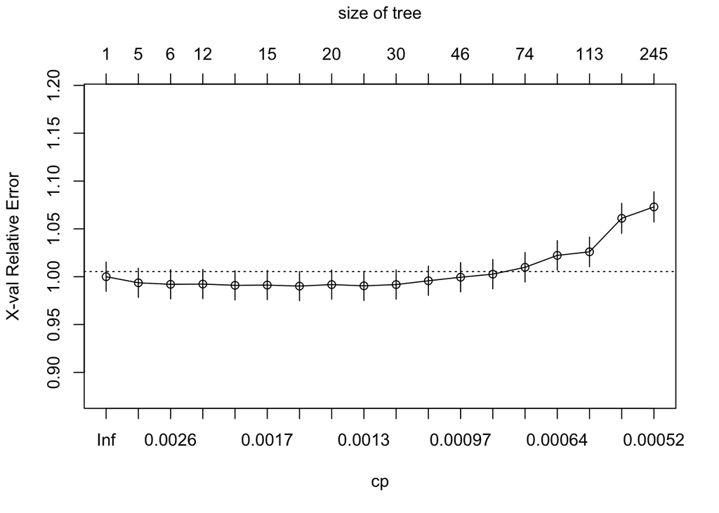

```r
plotcp(tree)
```

```r
prune(tree, cp=tree$cptable[which.min(tree$cptable[,"xerror"]),"CP"])
```

```
## n= 31824
##
## node), split, n, loss, yval, (yprob)
##       * denotes terminal node
##
##   1) root 31824 3769 0 (0.88156737 0.11843263)
##     2) mechvent_day01< 0.5 26043 2419 0 (0.90711516 0.09288484) *
##     3) mechvent_day01>=0.5 5781 1350 0 (0.76647639 0.23352361)
##       6) urineoutput_total_24>=731.5 4332  756 0 (0.82548476 0.17451524) *
##       7) urineoutput_total_24< 731.5 1449  594 0 (0.59006211 0.40993789)
##        14) wbc_max_24< 19.475 1065  374 0 (0.64882629 0.35117371)
##          28) albumin_min_24>=2.85 435  102 0 (0.76551724 0.23448276)
##            56) platelets_min_24>=60 419   89 0 (0.78758950 0.21241050) *
##            57) platelets_min_24< 60 16    3 1 (0.18750000 0.81250000) *
##          29) albumin_min_24< 2.85 630  272 0 (0.56825397 0.43174603)
##            58) me_sys_day1>=109.9361 236   77 0 (0.67372881 0.32627119) *
##            59) me_sys_day1< 109.9361 394  195 0 (0.50507614 0.49492386)
##             118) creat1< 0.56 21    2 0 (0.90476190 0.09523810) *
##             119) creat1>=0.56 373  180 1 (0.48257373 0.51742627)
##               238) urineoutput_total_24>=301 187   81 0 (0.56684492 0.43315508)
##                 476) me_hr_day1< 96.88396 100   34 0 (0.66000000 0.34000000) *
##                 477) me_hr_day1>=96.88396 87   40 1 (0.45977011 0.54022989) *
##               239) urineoutput_total_24< 301 186   74 1 (0.39784946 0.60215054)
##                 478) me_sys_day1< 90.55051 60   23 0 (0.61666667 0.38333333) *
##                 479) me_sys_day1>=90.55051 126   37 1 (0.29365079 0.70634921)
##                   958) albumin_min_24< 1.65 26   10 0 (0.61538462 0.38461538) *
##                   959) albumin_min_24>=1.65 100   21 1 (0.21000000 0.79000000) *
##        15) wbc_max_24>=19.475 384  164 1 (0.42708333 0.57291667)
##          30) platelets_min_24>=219.5 154   64 0 (0.58441558 0.41558442)
##            60) urineoutput_total_24>=557.5 50   11 0 (0.78000000 0.22000000) *
##            61) urineoutput_total_24< 557.5 104   51 1 (0.49038462 0.50961538)
##             122) creat1< 0.985 39   11 0 (0.71794872 0.28205128) *
##             123) creat1>=0.985 65   23 1 (0.35384615 0.64615385) *
##          31) platelets_min_24< 219.5 230   74 1 (0.32173913 0.67826087)
##            62) me_sys_day1>=117.0416 46   18 0 (0.60869565 0.39130435) *
##            63) me_sys_day1< 117.0416 184   46 1 (0.25000000 0.75000000) *
```

```r
#plot(tree, uniform=TRUE, main="Classification Tree")
#text(tree, use.n=TRUE, all=TRUE, cex=.5)
#varImp(tree)
```

# RF

```r
control <- trainControl(method='repeatedcv',number=10, repeats=1,search="grid")
metric <- "Accuracy"
tunegrid <- expand.grid(mtry=(1:4))
rf<- train(as.factor(aki)~chloride_twa_24+sodium_twa_24+SID_twa_24+ me_hr_day1+me_sys_day1+hst_temp+hemoglobin_min_24+platelets_min_24+albumin_min_24+wbc_max_24+mechvent_day01+urineoutput_total_24+gender+age_fixed+pasthistory_chf+pasthistory_pvd+pasthistory_hypertension+pasthistory_copd+pasthistory_diabetes+ethnicity, data=df_24h_1,method='rf', metric='Accuracy',tuneGrid=tunegrid, trControl=control)
print(rf)
plot(rf)
varImp(rf)
```

# Mortality

After finishing analyses for AKI, we can expand secondary outcomes as mortality.

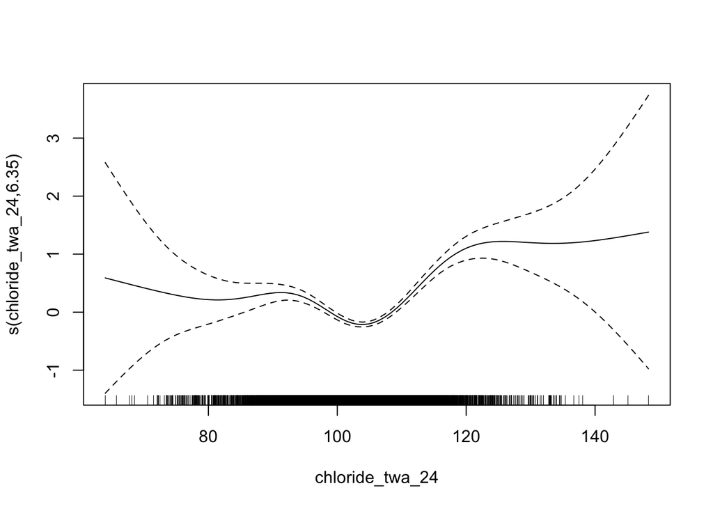

```r
gam<-gam(icumortality~s(chloride_twa_24,bs="tp",k=10),data=df_24h,family="binomial")
plot(gam)
```

```r
model<-glm(icumortality~cl_24_mean_cat+na_24_mean_cat+sid_24_mean_cat+
      me_hr_day1+me_sys_day1+hst_temp+hemoglobin_min_24+platelets_min_24+albumin_min_24+wbc_max_24+mechvent_day01+baseexcess_min_24+
      gender+age_fixed+pasthistory_chf+pasthistory_pvd+pasthistory_hypertension+pasthistory_copd+pasthistory_diabetes+ethnicity,data=df_2,family="binomial")
summary(model)
```

```
##
## Call:
## glm(formula = icumortality ~ cl_24_mean_cat + na_24_mean_cat +
##     sid_24_mean_cat + me_hr_day1 + me_sys_day1 + hst_temp + hemoglobin_min_24 +
##     platelets_min_24 + albumin_min_24 + wbc_max_24 + mechvent_day01 +
##     baseexcess_min_24 + gender + age_fixed + pasthistory_chf +
##     pasthistory_pvd + pasthistory_hypertension + pasthistory_copd +
##     pasthistory_diabetes + ethnicity, family = "binomial", data = df_2)
##
## Deviance Residuals:
##     Min       1Q   Median       3Q      Max
## -2.3124  -0.4516  -0.2975  -0.1836   3.2301
##
## Coefficients:
##                             Estimate Std. Error z value Pr(>|z|)
## (Intercept)               -1.8159636  0.4033180  -4.503 6.71e-06 ***
## cl_24_mean_cat1            0.4056466  0.1021110   3.973 7.11e-05 ***
## cl_24_mean_cat2           -0.0242166  0.0936240  -0.259  0.79590
## na_24_mean_cat1           -0.0490816  0.0900962  -0.545  0.58591
## na_24_mean_cat2            0.2248057  0.1064752   2.111  0.03474 *
## sid_24_mean_cat1          -0.5309114  0.0830620  -6.392 1.64e-10 ***
## sid_24_mean_cat2           0.5360973  0.0796824   6.728 1.72e-11 ***
## me_hr_day1                 0.0137012  0.0016916   8.099 5.52e-16 ***
## me_sys_day1               -0.0175911  0.0018449  -9.535  < 2e-16 ***
## hst_temp                  -0.0146822  0.0054311  -2.703  0.00686 **
## hemoglobin_min_24         -0.0161822  0.0128503  -1.259  0.20793
## platelets_min_24          -0.0017122  0.0002971  -5.763 8.28e-09 ***
## albumin_min_24            -0.5698351  0.0456177 -12.492  < 2e-16 ***
## wbc_max_24                 0.0128421  0.0029273   4.387 1.15e-05 ***
## mechvent_day01             0.9383683  0.0600769  15.619  < 2e-16 ***
## baseexcess_min_24         -0.0885388  0.0041535 -21.317  < 2e-16 ***
## gender1                    0.1136157  0.0576448   1.971  0.04873 *
## age_fixed                  0.0280115  0.0019776  14.164  < 2e-16 ***
## pasthistory_chf1           0.0871656  0.0765795   1.138  0.25502
## pasthistory_pvd1           0.2056187  0.1371787   1.499  0.13390
## pasthistory_hypertension1 -0.0554801  0.0601409  -0.923  0.35627
## pasthistory_copd1         -0.0934442  0.0701646  -1.332  0.18293
## pasthistory_diabetes1     -0.2795939  0.0868091  -3.221  0.00128 **
## ethnicityAsian             0.2190113  0.2438306   0.898  0.36907
## ethnicityCaucasian         0.0043236  0.1028392   0.042  0.96646
## ethnicityHispanic         -0.4948219  0.1687356  -2.933  0.00336 **
## ethnicityOther/Unknown    -0.0861278  0.1505817  -0.572  0.56734
## ---
## Signif. codes:  0 '***' 0.001 '**' 0.01 '*' 0.05 '.' 0.1 ' ' 1
##
## (Dispersion parameter for binomial family taken to be 1)
##
##     Null deviance: 11049.2  on 16269  degrees of freedom
## Residual deviance:  8702.9  on 16243  degrees of freedom
##   (91470 observations deleted due to missingness)
## AIC: 8756.9
##
## Number of Fisher Scoring iterations: 6
```

```r
model<-gam(icumortality~s(chloride_twa_24,bs="tp",k=10)+s(sodium_twa_24,bs="tp",k=10)+s(SID_twa_24,bs="tp",k=10)+me_hr_day1+me_sys_day1+hst_temp+hemoglobin_min_24+platelets_min_24+albumin_min_24+wbc_max_24+mechvent_day01+
      gender+age_fixed+pasthistory_chf+pasthistory_pvd+pasthistory_hypertension+pasthistory_copd+pasthistory_diabetes+ethnicity,data=df_2,family="binomial")
summary(model)
```

```
##
## Family: binomial
## Link function: logit
##
## Formula:
## icumortality ~ s(chloride_twa_24, bs = "tp", k = 10) + s(sodium_twa_24,
##     bs = "tp", k = 10) + s(SID_twa_24, bs = "tp", k = 10) + me_hr_day1 +
##     me_sys_day1 + hst_temp + hemoglobin_min_24 + platelets_min_24 +
##     albumin_min_24 + wbc_max_24 + mechvent_day01 + gender + age_fixed +
##     pasthistory_chf + pasthistory_pvd + pasthistory_hypertension +
##     pasthistory_copd + pasthistory_diabetes + ethnicity
##
## Parametric coefficients:
##                             Estimate Std. Error z value Pr(>|z|)
## (Intercept)               -1.6056363  0.3058859  -5.249 1.53e-07 ***
## me_hr_day1                 0.0214265  0.0012815  16.720  < 2e-16 ***
## me_sys_day1               -0.0272208  0.0014317 -19.014  < 2e-16 ***
## hst_temp                  -0.0236464  0.0041864  -5.648 1.62e-08 ***
## hemoglobin_min_24          0.0179013  0.0096373   1.857  0.06324 .
## platelets_min_24          -0.0026292  0.0002326 -11.303  < 2e-16 ***
## albumin_min_24            -0.5929843  0.0351527 -16.869  < 2e-16 ***
## wbc_max_24                 0.0257004  0.0021094  12.184  < 2e-16 ***
## mechvent_day01             1.6055106  0.0441487  36.366  < 2e-16 ***
## gender1                   -0.0272744  0.0435954  -0.626  0.53156
## age_fixed                  0.0267981  0.0014792  18.117  < 2e-16 ***
## pasthistory_chf1           0.1088037  0.0584260   1.862  0.06257 .
## pasthistory_pvd1           0.3404698  0.1047514   3.250  0.00115 **
## pasthistory_hypertension1 -0.0077852  0.0456603  -0.171  0.86462
## pasthistory_copd1         -0.1489706  0.0545494  -2.731  0.00632 **
## pasthistory_diabetes1     -0.1321567  0.0675987  -1.955  0.05058 .
## ethnicityAsian             0.2986654  0.1802059   1.657  0.09745 .
## ethnicityCaucasian         0.0643899  0.0809218   0.796  0.42620
## ethnicityHispanic         -0.2879441  0.1341744  -2.146  0.03187 *
## ethnicityOther/Unknown     0.0932561  0.1176595   0.793  0.42802
## ---
## Signif. codes:  0 '***' 0.001 '**' 0.01 '*' 0.05 '.' 0.1 ' ' 1
##
## Approximate significance of smooth terms:
##                      edf Ref.df Chi.sq  p-value
## s(chloride_twa_24) 1.864  2.444  4.023   0.1612
## s(sodium_twa_24)   6.246  7.295 36.772 8.55e-06 ***
## s(SID_twa_24)      5.238  6.378 16.784   0.0111 *
## ---
## Signif. codes:  0 '***' 0.001 '**' 0.01 '*' 0.05 '.' 0.1 ' ' 1
##
## R-sq.(adj) =  0.155   Deviance explained = 23.4%
## UBRE = -0.66929  Scale est. = 1         n = 49217
```